# Gender Pay Gap Exploratory Analyses

## Libraries

```r
# load packages
pacman::p_load(ggplot2, reader, gender, ggthemes, gridExtra, GGally, stringr,
    dplyr, tm, yarrr, DT, plotly, ggalt, tidyr, scales)
# check that packages were loaded
pacman::p_loaded(ggplot2, reader, gender, ggthemes, gridExtra, GGally, stringr,
    dplyr, tm, yarrr, DT, plotly, ggalt, tidyr, scales)
```

```
##   ggplot2    reader    gender  ggthemes gridExtra    GGally   stringr
##      TRUE      TRUE      TRUE      TRUE      TRUE      TRUE      TRUE
##     dplyr        tm     yarrr        DT    plotly     ggalt     tidyr
##      TRUE      TRUE      TRUE      TRUE      TRUE      TRUE      TRUE
##    scales
##      TRUE
```

## Data loading, feature creation, cleaning, pre-processing

Let’s load up the file first

```r
salaries <- read.csv("Salaries.csv", na.strings = c("Not Provided", " ", ""),
    strip.white = TRUE)
```

Let’s convert all the names to lower character and remove all punctuation.

```r
salaries$EmployeeName <- tolower(salaries$EmployeeName)
salaries$EmployeeName <- removePunctuation(salaries$EmployeeName)
# strip the left whitespace
salaries$EmployeeName <- trimws(salaries$EmployeeName, which = "left")
```

```r
filter(salaries, grepl("aaran", EmployeeName)) %>% select(EmployeeName, JobTitle,
    Year, TotalPay)
```

```
##   EmployeeName         JobTitle Year TotalPay
## 1  aaran y luo Transit Operator 2014 75252.84
## 2    aaran luo Transit Operator 2012 78118.96
## 3  aaran y luo Transit Operator 2013 82026.78
```

There are two conventions for how the employee name was recorded : `aaran y luo` or `aaran luo`. Nontheless, it would be highly unusual for these naming conventions to actually represent two different employees. Hence, I remove all the middle initial characters from the EmployeeName variable.

```r
salaries$EmployeeName <- gsub(" *\\b[[:alpha:]]{1}\\b *", " ", salaries$EmployeeName)
```

Now, let us create a new variable with the first names.

```r
salaries$name <- word(salaries$EmployeeName, 1)
```

Let’s use the Social Security Administration(`ssa`) gender data that represents the names prevelent in United States from 1930 to 2012. **If you’re using the `ssa` for the first time, you’ll need to wait a little bit for the genderData dependency to install.

```r
genderDF <- salaries %>% distinct(name) %>% do(results = gender(.$name, method = "ssa")) %>%
    do(bind_rows(.$results))

mergedDF <- salaries %>% left_join(genderDF, by = c(name = "name"))

rm(genderDF)
rm(salaries)
```

Now, let’s examine if there are any outliers present in the data. I’ll examine if there are any unusual values in total pay. First, I’ll examine the top 10 obervations for total pay and the bottom 10 observations in total pay.

```r
mergedDF %>% select(EmployeeName, JobTitle, TotalPayBenefits) %>% arrange(desc(TotalPayBenefits)) %>%
    head(10)
```

```
##         EmployeeName                                       JobTitle
## 1     nathaniel ford GENERAL MANAGER-METROPOLITAN TRANSIT AUTHORITY
## 2       gary jimenez                CAPTAIN III (POLICE DEPARTMENT)
## 3        david shinn                                 Deputy Chief 3
## 4           amy hart                              Asst Med Examiner
## 5  william coaker jr                       Chief Investment Officer
## 6       gregory suhr                                Chief of Police
## 7  joanne hayeswhite                         Chief, Fire Department
## 8       gregory suhr                                Chief of Police
## 9  joanne hayeswhite                         Chief, Fire Department
## 10     ellen moffatt                              Asst Med Examiner
##    TotalPayBenefits
## 1          567595.4
## 2          538909.3
## 3          510732.7
## 4          479652.2
## 5          436224.4
## 6          425815.3
## 7          422353.4
## 8          418019.2
## 9          417435.1
## 10         415767.9
```

It seems like we have some individuals who earn more than half a million dollars in pay, which is not that unusual considering the seniority of their positions and that SF is one of the most expensive cities in the US. It is interesting that Assistant Medical Examiners earn 400k. If you check the following link on [indeed.com](http://www.indeed.com/salary/q-Assistant-Medical-Examiner-l-San-Francisco,-CA.html), you’ll note that this job title generally gets about $65K a year. With that aside, let’s check the lowest salaries.

```r
mergedDF %>% select(EmployeeName, JobTitle, TotalPayBenefits) %>% arrange(desc(TotalPayBenefits)) %>%
    tail(10)
```

```
##              EmployeeName                   JobTitle TotalPayBenefits
## 148645      kaukab mohsin           TRANSIT OPERATOR             0.00
## 148646 josephine mccreary                 MANAGER IV             0.00
## 148647       not provided               Not provided             0.00
## 148648       not provided               Not provided             0.00
## 148649       not provided               Not provided             0.00
## 148650       not provided               Not provided             0.00
## 148651     timothy gibson           Police Officer 3            -2.73
## 148652       mark laherty           Police Officer 3            -8.20
## 148653        david kucia           Police Officer 3           -33.89
## 148654          joe lopez Counselor, Log Cabin Ranch          -618.13
```

```r
# remove not provided rows
mergedDF <- mergedDF %>% filter(EmployeeName != "not provided")

# remove joe lopez
mergedDF <- mergedDF %>% filter(TotalPayBenefits >= 0)

# check the rows with Total Pay of 0
zeroPay <- mergedDF %>% filter(TotalPayBenefits == 0) %>% select(EmployeeName,
    JobTitle, TotalPayBenefits)
datatable(zeroPay)
```

|  | EmployeeName | JobTitle | TotalPayBenefits |
| --- | --- | --- | --- |
| 1 | paulet gaines | Account Clerk | 0 |
| 2 | brett lundberg | General Laborer | 0 |
| 3 | mark mcclure | General Laborer | 0 |
| 4 | elizabeth iniguez | Transcriber Typist | 0 |
| 5 | randy keys | Carpenter | 0 |
| 6 | andre johnson | Communications Dispatcher 1 | 0 |
| 7 | sharon owenswebster | Protective Services Worker | 0 |
| 8 | edward ferdinand | General Laborer | 0 |
| 9 | david turner | Transit Car Cleaner | 0 |
| 10 | james kibblewhite | General Laborer | 0 |

[output cut: 16 more lines]

We have 26 individuals who had 0 pay. One reason why their pay was 0 is that they just registered as employees and did not recieve a salary yet. Another reason is that they are registered as employees, but had to take a sabatical with no pay. Regardless of the reason, the number of people with zero pay is really small and we can feel safe removing them.

```r
mergedDF <- mergedDF %>% filter(TotalPayBenefits != 0)
```

Even though we removed employees with zero pay, we still need to explore if there are individuals who recieved really low pay. Let’s examine the distribution of the TotalPayBenefits variable in order to answer that question. I will break the distribution of total pay by Status (FT=Full Time, PT=Part Time, NA)

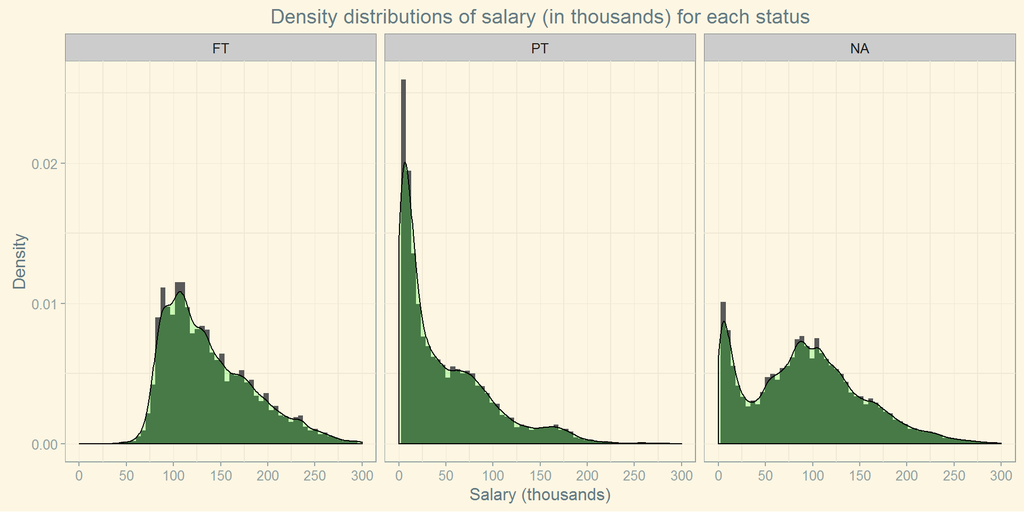

```r
theme_set(theme_solarized())
ggplot(mergedDF, aes(x = TotalPayBenefits/1000)) + geom_histogram(aes(y = ..density..),
    binwidth = density(mergedDF$TotalPayBenefits/1000)$bw) + geom_density(fill = "green",
    alpha = 0.2) + facet_grid(. ~ Status) + scale_x_continuous(breaks = seq(0,
    300, 50), limits = c(0, 300)) + ggtitle("Density distributions of salary (in thousands) for each status") +
    labs(y = "Density", x = "Salary (thousands)")
```

It seems like we have two groups of individuals. One group represents the part timers and the other represents the group that had a full time salary. The NA responses have a mixture of the two groups (note the bimodality in the distribution of responses). There are a couple observations to be made:

- The full time employees seem to earn at least 50k salary.
- The part time employees have a much wider range in salary, with salaries starting at near 0 to 300k.

Let’s look at the gender counts for the Full Time and Part Time employees. We’ll leave employees with NA aside for now.

```r
# remove data for which no gender is available; this removed about 10,000
# observations.
genderDF <- mergedDF %>% filter(gender != "NA")

# remove the jobs with NA status.
genderDF <- genderDF %>% filter(Status != "NA")
```

```r
countsDf <- genderDF %>% count(Status, gender)

counts <- ggplot(data = countsDf, aes(x = Status, y = n, fill = gender)) + geom_bar(stat = "identity",
    position = position_dodge(), colour = "black") + scale_fill_manual(values = c("#999999",
    "#E69F00")) + ggtitle("Number of employees by gender and status") + labs(y = "# Employees",
    x = "Status")
```

```r
ggplotly(counts)
```

[interactive chart not shown]

It seems like more females are working part relative to males. Moreover, it seems like there are more male full time employees than part time female employees. Let us check the pay distribution for full time and the part time male and female employees

```r
meanGenderDf <- genderDF %>% select(Status, gender, TotalPayBenefits) %>% filter(TotalPayBenefits >=
    quantile(TotalPayBenefits, 0.01), TotalPayBenefits <= quantile(TotalPayBenefits,
    0.99)) %>% group_by(Status, gender) %>% summarise(meanSalary = mean(TotalPayBenefits))

meanPlot <- ggplot(data = meanGenderDf, aes(x = Status, y = meanSalary/1000,
    fill = gender)) + geom_bar(stat = "identity", position = position_dodge(),
    colour = "black") + scale_fill_manual(values = c("#999999", "#E69F00")) +
    ggtitle("Mean Salary by gender and status") + labs(y = "Mean Salary", x = "Status") +
    scale_y_continuous(breaks = seq(0, 160, 20), labels = sprintf("$%sK", comma(seq(0,
        160, by = 20))))

ggplotly()
```

[interactive chart not shown]

It seems like fully employed men earn on average higher salary than females. **Fully employed women earn about 89cents for every dollar earned by fully employed men.**

Let’s see if the same pattern holds for median salary

```r
medianGenderDF <- genderDF %>% select(Status, gender, TotalPayBenefits) %>%
    group_by(Status, gender) %>% summarise(medianSalary = median(TotalPayBenefits))


medianPlot <- ggplot(data = medianGenderDF, aes(x = Status, y = medianSalary/1000,
    fill = gender)) + geom_bar(stat = "identity", position = position_dodge(),
    colour = "black") + scale_fill_manual(values = c("#999999", "#E69F00")) +
    ggtitle("Median Salary by gender and status") + labs(y = "Median Salary",
    x = "Status") + scale_y_continuous(breaks = seq(0, 160, 20), labels = sprintf("$%sK",
    comma(seq(0, 160, by = 20))))

ggplotly()
```

[interactive chart not shown]

The picture looks even worse. **On median, fully employed women earn about 84 cents for every dollar earned by fully employed males.**

Stas Sajin

2016-05-19